# Sensitivity with ODEs

# Extracting meaning from time series output

Useful to brainstorm about what is important

For example

- time it takes to evenly diffuse?

How would we implement that?

# Extracting information from space-time results

- pictures can be hard to interpret
- summarizing over one of the dimensions (either space or time) can help
- looking at a single trajectory through time
- looking at spatial variation for one point in time
- looking at spatial variation for multiple points in time

# Try it

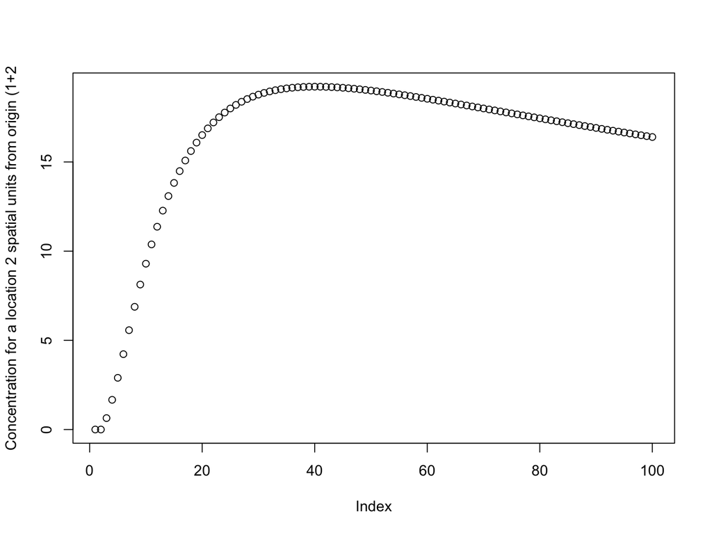

```r
#View(resfast_fixtime$conc)


# graph a single point in space through time
# single column (time)
plot(resfast_fixtime$conc[,3], ylab="Concentration for a location 2 spatial units from origin (1+2")
```

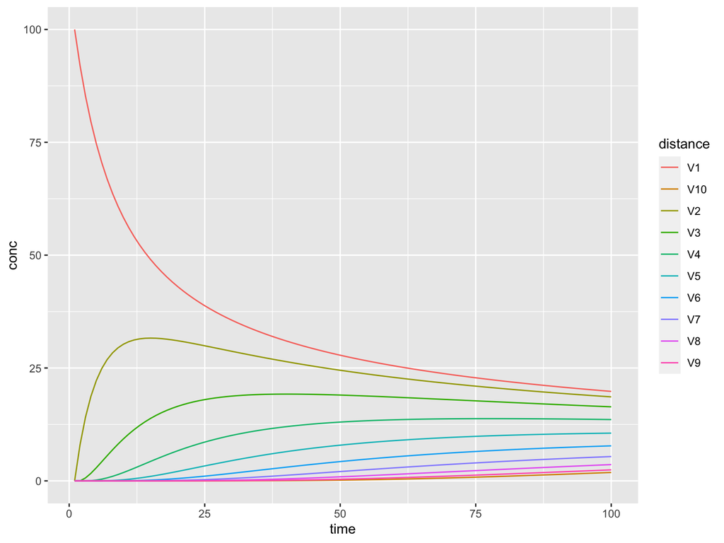

```r
# plot all trajectories
# add a time column to concentration data frame and transform for plotting
resl = as.data.frame(resfast_fixtime$conc) %>% mutate(time=seq(from=1, to=100)) %>% pivot_longer(-time, names_to="distance", values_to="conc")
ggplot(resl, aes(time, conc, col=distance))+geom_line()
```

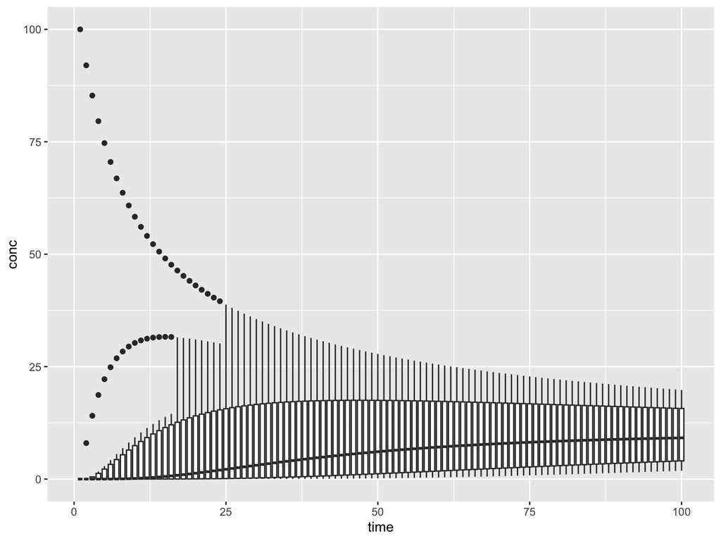

```r
# plot all places at each point in time
ggplot(resl, aes(time, conc, group=time))+geom_boxplot()
```

```r
# use apply to calculate the spatial variation for each row (e.g for each time point)
cvar = resfast_fixtime$conc %>% apply(1,var)
cmean = resfast_fixtime$conc %>% apply(1, mean)

spatial_aver = cbind.data.frame(cvar, cmean, time=seq(from=1,to=100))
length(cvar)
```

```
## [1] 100
```

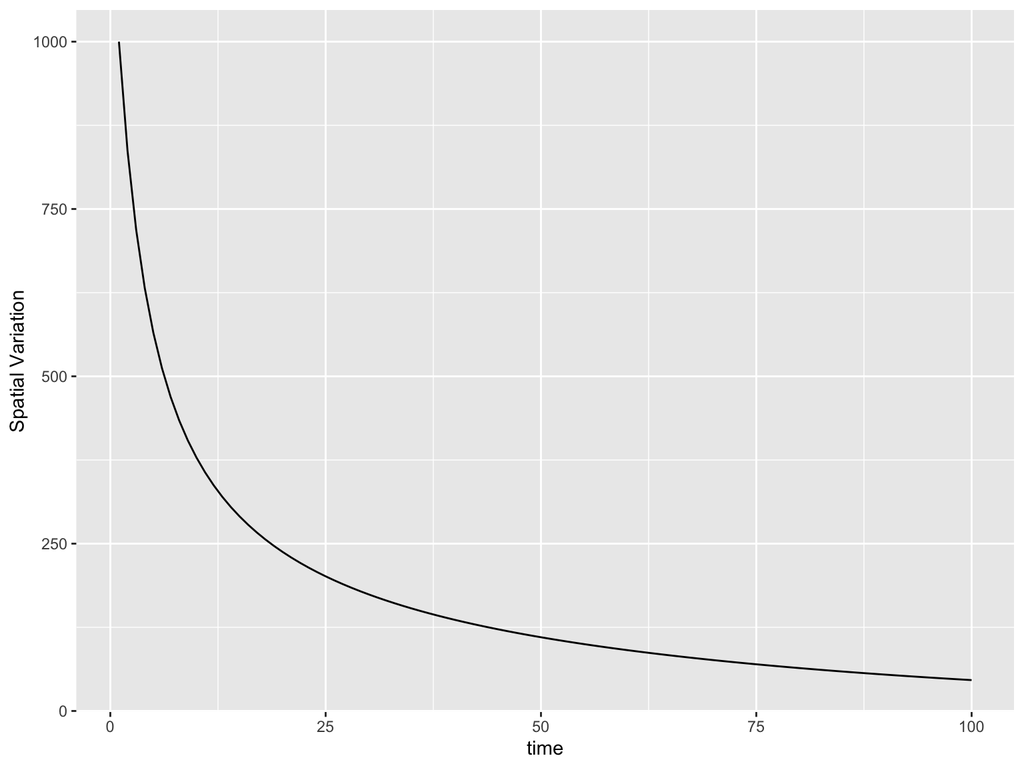

```r
# notice its the same as the number of time units (nt) used above

# plot spatial variation through time
ggplot(spatial_aver, aes(time, cvar))+geom_line()+labs(y="Spatial Variation")
```

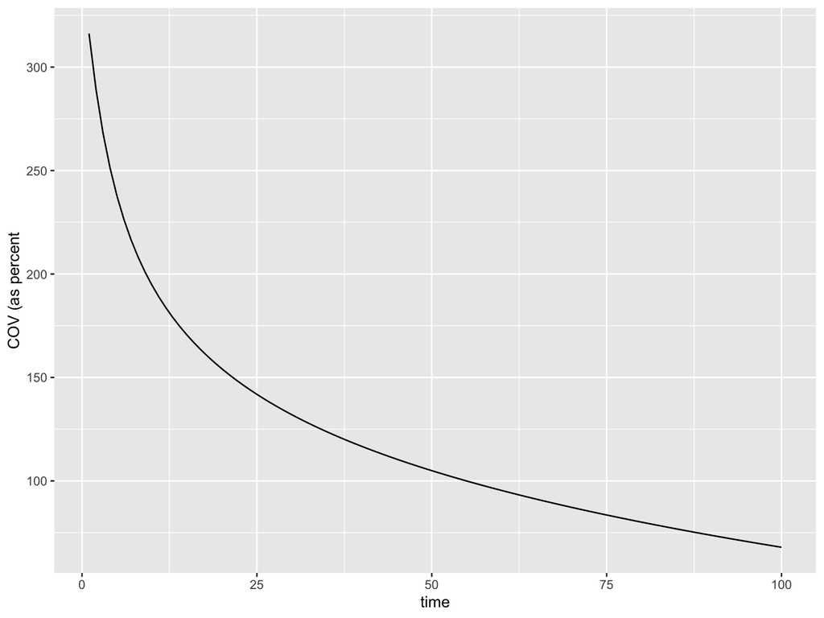

```r
# plot coefficient of variation (so standard deviation divided by the mean)
ggplot(spatial_aver, aes(time, 100*sqrt(cvar)/cmean))+geom_line()+labs(y="COV (as percent")
```

# Sensitivity Analysis of a differential equation

We can apply sensitivity analysis to a differential equation

A key issue where is sensitivity of what?

Dynamic models often give you many many outputs - time series (streamflow every day for a year, population for 30 years) - or output over space (spatially averaged concentration after 10 days?)

So if we are asking ‘sensitivity of what’ we need to summarize results in some way (reduce their dimensionality )

Ideas?

# Some options for reducing output dimensionality (summarizing output)

Depends on what is important for your model application

- max
- mean
- min
- total
- variation
- time it takes for something to happen

So a key step in sensitivity analysis with a dynamics model is summarizing results into a few key measures

Its useful to turn that summarizing workflow into a function

## Workflow

- obtain parameter sets (from sobel of LHS)
- build a function that will extract the information (metrics) you want from your dynamic model (output of the ode)
- create a data structure to store the metrics for each parameter set - lets call it metrics (but could be anything)
- run ODE for each parameter sets to fill in this metrics data structure
- send the metrics data structure back to the sensitivity analysis object (from sobel or LHS)
- plot and analyze results

# Example with our population ODE

```r
source("../R/dpopgrowth.R")

dpopgrowth
```

```
## function (Time, P, parms)
## {
##     dP = parms$r * P * (1 - P/parms$K)
##     return(list(dP))
## }
```

```r
# lets start with sobel
library(sensitivity)

# come up with first set of sample parameters
# we will assume that we know the initial population,

Pinitial=10

# want to learn about sensitivity to growth rate (r) and carrying capacity
# set the number of parameters
np=2000
K = rnorm(mean=200, sd=50, n=np)
r = rnorm(mean=0.05, sd=0.01, n=np)
X1 = cbind.data.frame(r=r, K=K)

# repeat to get our second set of samples
K = rnorm(mean=200, sd=50, n=np)
r = rnorm(mean=0.05, sd=0.01, n=np)
X2 = cbind.data.frame(r=r, K=K)

# fix any negative values and they are not meaningful
X1 = X1 %>% map_df(pmax, 0.0)
X2 = X2 %>% map_df(pmax, 0.0)

# create our sobel object and get sets ofparameters for running the model

sens_P = sobolSalt(model = NULL,X1, X2, nboot = 300)

# our parameter sets are
head(sens_P$X)
```

```
##            [,1]     [,2]
## [1,] 0.05643164 179.2177
## [2,] 0.04972374 219.6321
## [3,] 0.03809873 195.3423
## [4,] 0.07044473 233.2206
## [5,] 0.05229311 202.0078
## [6,] 0.03772966 272.0241
```

```r
# lets add names
colnames(sens_P$X) = c("r","K")

# run our differential equation and keep the output
# BUT
# what output do we want  to keep
# how about maximum population if we run the model for 200 years, and how many years to get to the carrying capacity

# for illustration lets look at running just one parameter sets and summarizing results
sens_P$X[1,]
```

```
##            r            K
##   0.05643164 179.21774657
```

```r
# recall ODE needs ALL of our parameters in a single list
# initial population and times for which we want output
Pinitial
```

```
## [1] 10
```

```r
# gets results for 200 years (evaluating every year)
simtimes = seq(from=1, to=200)
parms = list(r=sens_P$X[1,"r"], K=sens_P$X[1,"K"])

# or
parms = list(r=as.data.frame(sens_P$X)$r[1], K=as.data.frame(sens_P$X)$K[1])

result = ode(y=Pinitial, times=simtimes, func=dpopgrowth, parms=parms)

head(result)
```

```
##      time        1
## [1,]    1 10.00000
## [2,]    2 10.54639
## [3,]    3 11.12065
## [4,]    4 11.72402
## [5,]    5 12.35771
## [6,]    6 13.02300
```

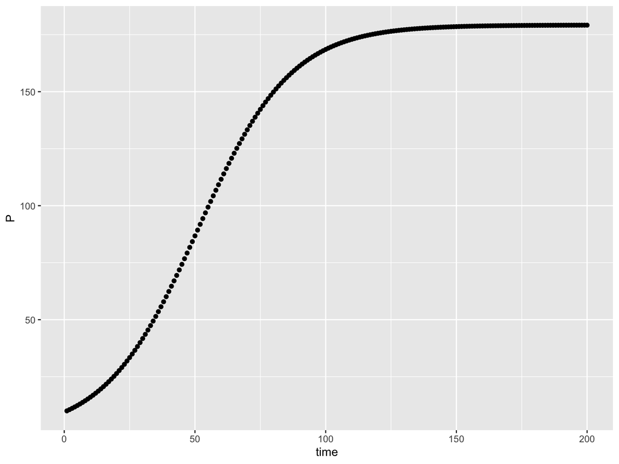

```r
colnames(result)=c("time","P")
# turn it into a data frame
result = as.data.frame(result)
ggplot(result, aes(time, P))+geom_point()
```

```r
# extra our metrics of interest  from this
# maximum population it gets to
maxpop = max(result$P)
maxpop
```

```
## [1] 179.1775
```

```r
# years required to get to a threshold population (150)
# which will tell when this occurs - we will take the first one
thresh = 150
idx = which(result$P > thresh)[1]

# if it never gets there
idx = ifelse(is.na(idx), length(result$P), idx)
# turn this index into a year (might be the same if time step in 1 but just in case it isn't)
threshyear = result$time[idx]
threshyear
```

```
## [1] 81
```

```r
# or how about threshold of 50% of carrying capacity
thresh = 0.5*sens_P$X[1,"K"]
idx = which(result$P > thresh)[1]

# if it never gets there
idx = ifelse(is.na(idx), length(result$P), idx)
# turn this index into a year (might be the same if time step in 1 but just in case it isn't)
threshyear = result$time[idx]
threshyear
```

```
## [1] 52
```

# Try it running ODE for different parameters

# Compute our metric for all the parameter sets

What if we want to run for all parameters

Lets create two additional functions that will help us

- a function that computes the metrics we want
- a function that runs our ode solver and computes the metrics (I call it a wrapper function as it is really just a workflow/wrapper to call ode solver and then compute metrics)

[output not shown]

[figure not shown]

# Compute the sobol indicies for each metric

```r
# sobol can only handle one output at a time  - so we will need to do them separately

sens_P_maxpop = sensitivity::tell(sens_P,allres$maxpop)

# first-order indices (main effect without co-variance)
sens_P_maxpop$S
```

```
##     original          bias  std. error   min. c.i.  max. c.i.
## X1 0.0219319  2.028805e-04 0.024068676 -0.02293398 0.07075768
## X2 0.9897568 -8.976528e-05 0.003105837  0.98487774 0.99677415
```

```r
# total sensitivity index -note that this partitions the output variance
sens_P_maxpop$T
```

```
##      original          bias  std. error  min. c.i.   max. c.i.
## X1 0.00678185  6.087719e-05 0.001616078 0.00300843 0.009286097
## X2 0.97548713 -5.176245e-04 0.023816719 0.92731148 1.020005061
```

```r
# create another one for max year
sens_P_threshyear = sensitivity::tell(sens_P,allres$threshyear)
# first-order indices (main effect without co-variance)
sens_P_threshyear$S
```

```
##     original          bias std. error min. c.i. max. c.i.
## X1 0.3436480 -0.0001715754 0.03297692 0.2776682 0.4093982
## X2 0.6580521 -0.0019800896 0.03104893 0.6046166 0.7237792
```

```r
# total sensitivity index -note that this partitions the output variance - so values sum to 1
sens_P_threshyear$T
```

```
##     original         bias std. error min. c.i. max. c.i.
## X1 0.3456629 0.0008225024 0.03346576 0.2787434 0.4090028
## X2 0.6583596 0.0021681604 0.03575223 0.5876124 0.7234621
```

# Negative sobol first order indices

if confidence interval includes zero - not a problem

if it doesn’t there are numerical issues - try running more samples

# Error messages from ODE

*In lsoda(y, times, func, parms, …) : an excessive amount of work (> maxsteps ) was done, but integration was not successful - increase maxsteps*

Suggest that the solver (numerical integration) had issues

- increasing maxsteps can help

  ```
  *result = ode(y=Pinitial, times=simtimes, func=func, parms=parms, maxsteps=100000) *
  ```

- trying different methods

  ```
  *result = ode(y=Pinitial, times=simtimes, func=func, parms=parms, method="daspk")*
  ```

- “stiff” problems are harder for numerical integration to solve - (small changes have big impacts); our threshold carrying capacity does that - change to make is a more smooth transition

  thoughts on how to do this?

# For next class (not to hand in - just practice on your own)

Go through in-class examples;

- try varying parameter ranges,
- try changing the population growth function to smooth the transition to no growth when a carrying capacity is approached ;
- try developing a different metric

We will go over this in class on Thursday

Want to go further?….

Try using Sobol for the diffusion model - what would be your metric?